# Automatiza la publicación de tus reportes

con Quarto y GitHub Actions

Jesica Formoso

jesica.formoso@gmail.com

CIIPME-CONICET | MetaDocencia 🍎

María Cristina Nanton

mcnanton@gmail.com

GCBA | TGHN | UBA

## ¡Hola!👋

[figure not shown]

**María Cristina Nanton**  
Coordinación en Ciencia de Datos en Gerencia de Información y Estadísticas en Salud (GCBA)  
AI Dev en The Global Health Network  
R-Ladies Buenos Aires💜  
Colaboradora  
en MetaDocencia🍎

[figure not shown]

**Jesica Formoso**  
Investigadora Adjunta,  
CIIPME-CONICET  
Medición de Impacto en Metadocencia🍎  
R-Ladies Buenos Aires 💜

## Qué vamos a ver hoy

### Agenda

- Conceptos básicos para trabajar con GitHub Actions, GH Pages y Quarto
- Preparación de un entorno de trabajo para flujos *bien* automatizados
- Creación de un flujo automatizado de publicación en GH Pages basado en pushes a un repositorio
- Adaptación a ejecuciones periódicas

## Qué vamos a implementar hoy

Un sitio publicado en GH Pages generado desde Quarto alimentado de manera periódica y automatizada a partir de respuestas a un formulario con orquestación via GH Actions

[figure not shown]

# CI/CD y GitHub Actions

**Conceptos básicos**

## GitHub y GitHub Actions

**GitHub**

Plataforma orientada al desarrollo de software que integra repositorios con control de versiones con un enfoque de desarrollo colaborativo

[figure not shown]

**GitHub Actions**

Herramienta de integración y deploy continuo (CI/CD) que permite automatizar el trabajo con código, desde los testeos hasta la publicación de productos

## ¿CI/CD?

> La integración continua (CI) consiste en integrar los cambios del código en un repositorio de código fuente compartido de forma automática y frecuente.La implementación o distribución continua (CD) es un proceso de dos partes que implica la integración, la prueba y la distribución de los cambios en el código.

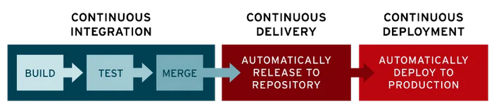

*Fuente: Red Hat*

## Ejemplos no tan *lejanos*

**rOpenSci** usa CI/CD con GHA para actualizar su Guía de desarrollo!

[figure not shown]

[figure not shown]

[figure not shown]

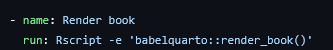

## Ejemplos no tan *lejanos*

**Turing Way** usa CI/CD con GHA para flujos de chequeo y publicación: por ejemplo, para revisar el mal uso del latin en sus publicaciones!

[figure not shown]

[figure not shown]

[figure not shown]

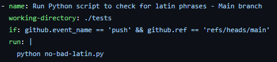

## ¿Notaron el uso de YAML?

Las GHA usan sintaxis YAML para organizar las automatizaciones.

[figure not shown]

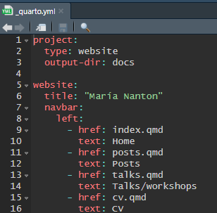

## ¿Qué vamos a incluir en este YAML?

¡Todo lo que un proyecto de Quarto con R necesita para ejecutarse de manera automática!

- Quarto, por supuesto
- R para procesar nuestros datos
- Un repositorio donde este alojado nuestro archivo Qmd

## ¿Qué vamos a incluir en este YAML?

¡Todo lo que un proyecto de Quarto con R necesita para ejecutarse de manera automática!

- Quarto, por supuesto
- R para procesar nuestros datos
- Un repositorio donde este alojado nuestro archivo Qmd

Y además:

- Instrucciones sobre cuándo correr las automatizaciones…
- … y una máquina virtual que las ejecute…
- … que pueda acceder a las dependencias necesarias e instalarlas!

## De nuestra PC a GHA

[figure not shown]

## Instalación de dependencias

### Biblioteca `renv`

[figure not shown]

Herramienta que permite **capturar** todas las bibliotecas que usadas en un proyecto e **instalarlas** si es necesario

Símil `venv` si vienen de manejar Python

## ¿Dónde *corre* todo esto en una ejecución automatizada?

Una máquina virtual (VM) es una manera de emular un equipo físico (como nuestras computadoras) en todos sus aspectos: espacio de almacenamiento, memoria y **sistema operativo**.

Son entornos aislados que podemos utilizar para ejecutar procesos.

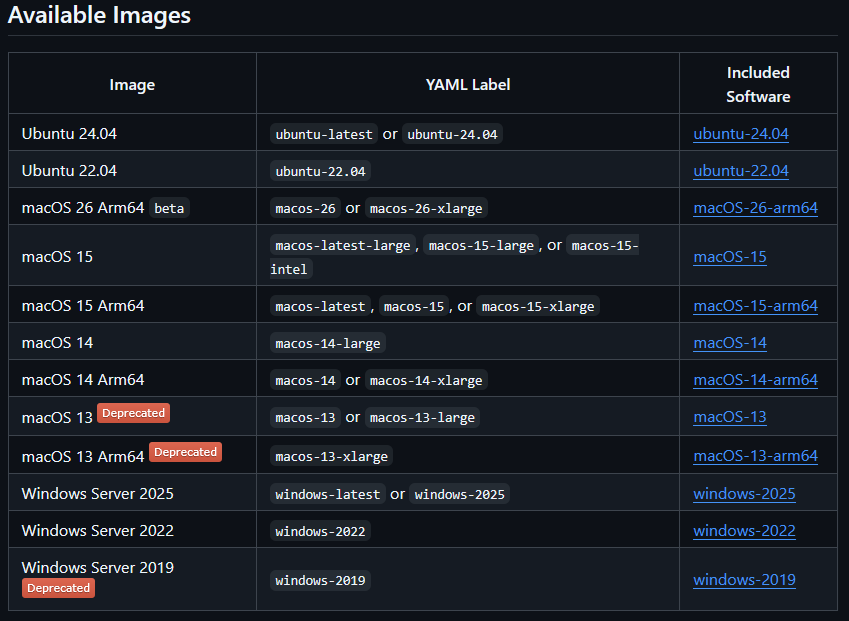

## Dándole ritmo a la automatización

### Programación de tareas con crontab

En sistemas operativos Unix, **cron** es un administrador de procesos para ejecutarlos a intervalos regulares

### Expresiones CRON

```
* * * * *   comando-a-ejecutar
| | | | |
| | | | └── Día de la semana (0-7, donde 0 y 7 representan domingo)
| | | └──── Mes (1-12)
| | └────── Día del mes (1-31)
| └──────── Hora (0-23)
└────────── Minuto (0-59)
```

## CRON

Con estas expresiones podemos ordenar la ejecución de procesos con cualquier periodicidad

```
0 * * * *   revisar_cada_una_hora
| | | | |
| | | | └── Día de la semana (todos)
| | | └──── Mes (todos)
| | └────── Día del mes (todos)
| └──────── Hora (todos)
└────────── Minuto (al minuto 0, es decir, el inicio de cada hora)
```

## Del código al HTML

[figure not shown]

**Quarto**

Herramienta para generar artículos, sitios o publicaciones en formatos word, pdf, html, entre otros

[figure not shown]

**Github Pages**

Herramienta de GitHub para crear sitios web directamente desde el contenido de un repositorio

## Ahora sí: la infraestructura de nuestra automatización

[figure not shown]

# Mini-evaluación 1

Vamos a usar las reacciones de zoom para preguntas de opción múltiple

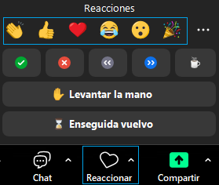

## Mini-evaluación 1:

### ¿Qué herramiena permite controlar los paquetes necesarios para reproducir el proyecto en GitHub Actions?

👍 Quarto

😮 renv

👏 GitHub

## Mini-evaluación 1:

### ¿Qué formato utilizan los archivos de configuración de las GitHub Actions?

👍 YAML

😮 .workflow

👏 cron

## Mini-evaluación 1:

### ¿Cuál es el sistema operativo de la máquina que ejecutará las Github Actions?

👍 El de la computadora en la que se redactó el código

😮 El que elija GitHub para mi acción

👏 El de la máquina virtual que configure yo

# Break (5 minutos)

# Preparando nuestro entorno

**Recorrido por los elementos del proyecto en el repositorio**

## Pasos previos a generar la GitHub Action

- Creamos el form y la hoja de cálculo con acceso a cualquiera vía link
- Creamos un proyecto de Quarto (website)
  - inicializamos git
  - inicializamos renv
- Creamos el repositorio remoto en GitHub
- Armamos el reporte o dashboard en el archivo **index.qmd**
  - renv::snapshot()
- Conectamos el repositorio local y el remoto desde la terminal de R
- Actualizamos los cambios (commit y push)

# Break (5 minutos)

# Workflow de Github Actions

**Combinamos los elementos para un flujo automatizado**

[figure not shown]

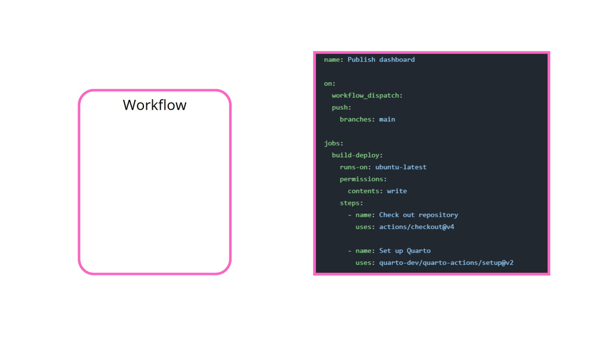

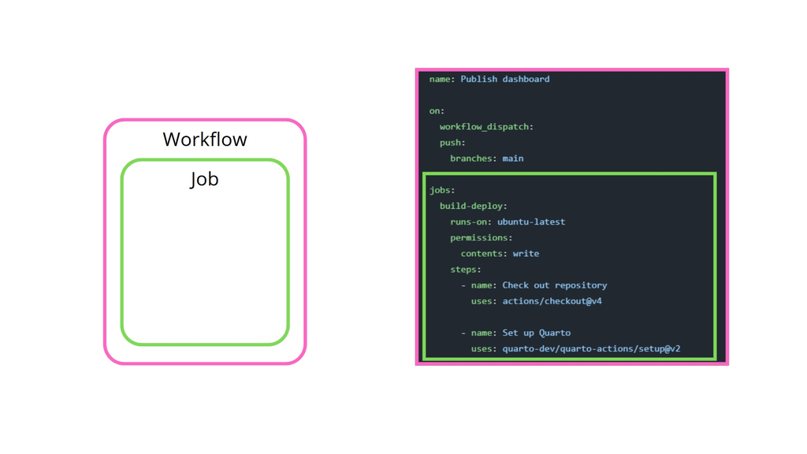

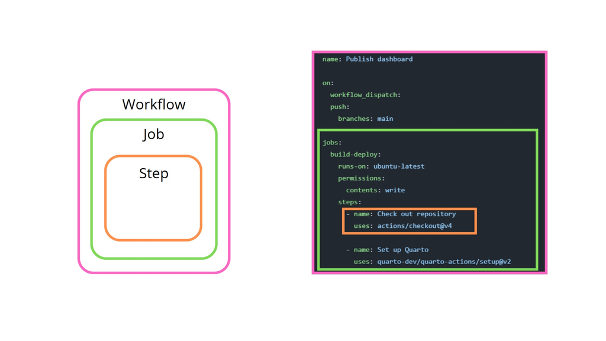

[figure not shown]

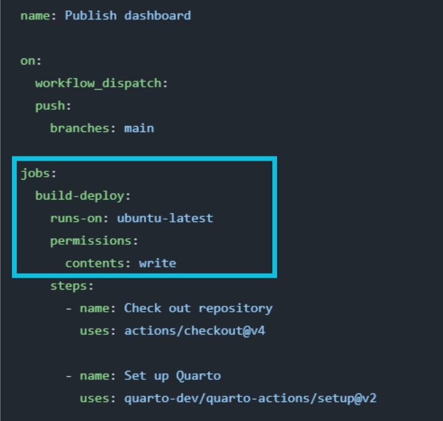

- **build-deploy** es el identificador del **job**
- **runs-on** indica el tipo de máquina (runner) donde se ejecutará el **job**

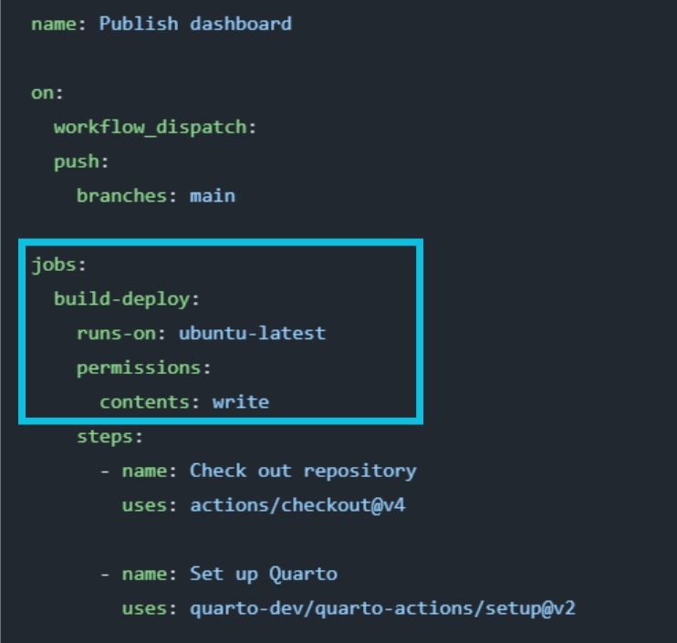

- **permissions** configura qué puede hacer el **job** sobre el contenido del repositorio:
  - **write:** permiso de escritura (crear archivos, releases, actualizar archivos)
  - **read:** permiso de lectura (no puede modificar el repositorio)
  - Se puede especificar de forma global o a nivel de cada **job**